# Risk Factor Analysis

## Outcome Variable

**Outcome Variable:** ever_sstunted

## Predictor Variables

**Intervention Variable:** parity

**Adjustment Set:**

- arm
- W_mage
- meducyrs
- feducyrs
- hhwealth_quart
- W_mhtcm
- W_mwtkg
- W_mbmi
- vagbrth
- W_nrooms
- impsan
- delta_W_mage
- delta_meducyrs
- delta_feducyrs
- delta_hhwealth_quart
- delta_W_mhtcm
- delta_W_mwtkg
- delta_W_mbmi
- delta_vagbrth
- delta_W_nrooms
- delta_impsan

## Stratifying Variables

The analysis was stratified on these variable(s):

- agecat
- studyid
- country

## Data Summary

| agecat | studyid | country | parity | ever_sstunted | n_cell | n |
| --- | --- | --- | --- | --- | --- | --- |
| 0-24 months | COHORTS | GUATEMALA | 1 | 0 | 121 | 1360 |
| 0-24 months | COHORTS | GUATEMALA | 1 | 1 | 92 | 1360 |
| 0-24 months | COHORTS | GUATEMALA | 2 | 0 | 105 | 1360 |
| 0-24 months | COHORTS | GUATEMALA | 2 | 1 | 87 | 1360 |
| 0-24 months | COHORTS | GUATEMALA | 3+ | 0 | 503 | 1360 |
| 0-24 months | COHORTS | GUATEMALA | 3+ | 1 | 452 | 1360 |
| 0-24 months | COHORTS | INDIA | 1 | 0 | 723 | 4630 |
| 0-24 months | COHORTS | INDIA | 1 | 1 | 89 | 4630 |
| 0-24 months | COHORTS | INDIA | 2 | 0 | 1061 | 4630 |
| 0-24 months | COHORTS | INDIA | 2 | 1 | 124 | 4630 |
| 0-24 months | COHORTS | INDIA | 3+ | 0 | 2205 | 4630 |
| 0-24 months | COHORTS | INDIA | 3+ | 1 | 428 | 4630 |
| 0-24 months | COHORTS | PHILIPPINES | 1 | 0 | 505 | 3058 |
| 0-24 months | COHORTS | PHILIPPINES | 1 | 1 | 173 | 3058 |
| 0-24 months | COHORTS | PHILIPPINES | 2 | 0 | 470 | 3058 |
| 0-24 months | COHORTS | PHILIPPINES | 2 | 1 | 220 | 3058 |
| 0-24 months | COHORTS | PHILIPPINES | 3+ | 0 | 994 | 3058 |
| 0-24 months | COHORTS | PHILIPPINES | 3+ | 1 | 696 | 3058 |
| 0-24 months | GMS-Nepal | NEPAL | 1 | 0 | 159 | 698 |
| 0-24 months | GMS-Nepal | NEPAL | 1 | 1 | 52 | 698 |
| 0-24 months | GMS-Nepal | NEPAL | 2 | 0 | 143 | 698 |
| 0-24 months | GMS-Nepal | NEPAL | 2 | 1 | 38 | 698 |
| 0-24 months | GMS-Nepal | NEPAL | 3+ | 0 | 227 | 698 |
| 0-24 months | GMS-Nepal | NEPAL | 3+ | 1 | 79 | 698 |
| 0-24 months | JiVitA-3 | BANGLADESH | 1 | 0 | 7949 | 27227 |
| 0-24 months | JiVitA-3 | BANGLADESH | 1 | 1 | 2303 | 27227 |
| 0-24 months | JiVitA-3 | BANGLADESH | 2 | 0 | 7618 | 27227 |
| 0-24 months | JiVitA-3 | BANGLADESH | 2 | 1 | 1381 | 27227 |
| 0-24 months | JiVitA-3 | BANGLADESH | 3+ | 0 | 6638 | 27227 |
| 0-24 months | JiVitA-3 | BANGLADESH | 3+ | 1 | 1338 | 27227 |
| 0-24 months | Keneba | GAMBIA | 1 | 0 | 182 | 1990 |
| 0-24 months | Keneba | GAMBIA | 1 | 1 | 59 | 1990 |
| 0-24 months | Keneba | GAMBIA | 2 | 0 | 173 | 1990 |
| 0-24 months | Keneba | GAMBIA | 2 | 1 | 41 | 1990 |
| 0-24 months | Keneba | GAMBIA | 3+ | 0 | 1158 | 1990 |
| 0-24 months | Keneba | GAMBIA | 3+ | 1 | 377 | 1990 |
| 0-24 months | PROVIDE | BANGLADESH | 1 | 0 | 227 | 700 |
| 0-24 months | PROVIDE | BANGLADESH | 1 | 1 | 44 | 700 |
| 0-24 months | PROVIDE | BANGLADESH | 2 | 0 | 214 | 700 |
| 0-24 months | PROVIDE | BANGLADESH | 2 | 1 | 30 | 700 |
| 0-24 months | PROVIDE | BANGLADESH | 3+ | 0 | 164 | 700 |
| 0-24 months | PROVIDE | BANGLADESH | 3+ | 1 | 21 | 700 |
| 0-24 months | SAS-CompFeed | INDIA | 1 | 0 | 310 | 1533 |
| 0-24 months | SAS-CompFeed | INDIA | 1 | 1 | 142 | 1533 |
| 0-24 months | SAS-CompFeed | INDIA | 2 | 0 | 261 | 1533 |
| 0-24 months | SAS-CompFeed | INDIA | 2 | 1 | 99 | 1533 |
| 0-24 months | SAS-CompFeed | INDIA | 3+ | 0 | 455 | 1533 |
| 0-24 months | SAS-CompFeed | INDIA | 3+ | 1 | 266 | 1533 |
| 0-24 months | SAS-FoodSuppl | INDIA | 1 | 0 | 17 | 418 |
| 0-24 months | SAS-FoodSuppl | INDIA | 1 | 1 | 4 | 418 |
| 0-24 months | SAS-FoodSuppl | INDIA | 2 | 0 | 46 | 418 |
| 0-24 months | SAS-FoodSuppl | INDIA | 2 | 1 | 31 | 418 |
| 0-24 months | SAS-FoodSuppl | INDIA | 3+ | 0 | 154 | 418 |
| 0-24 months | SAS-FoodSuppl | INDIA | 3+ | 1 | 166 | 418 |
| 0-24 months | TanzaniaChild2 | TANZANIA, UNITED REPUBLIC OF | 1 | 0 | 750 | 2357 |
| 0-24 months | TanzaniaChild2 | TANZANIA, UNITED REPUBLIC OF | 1 | 1 | 71 | 2357 |
| 0-24 months | TanzaniaChild2 | TANZANIA, UNITED REPUBLIC OF | 2 | 0 | 688 | 2357 |
| 0-24 months | TanzaniaChild2 | TANZANIA, UNITED REPUBLIC OF | 2 | 1 | 83 | 2357 |
| 0-24 months | TanzaniaChild2 | TANZANIA, UNITED REPUBLIC OF | 3+ | 0 | 685 | 2357 |
| 0-24 months | TanzaniaChild2 | TANZANIA, UNITED REPUBLIC OF | 3+ | 1 | 80 | 2357 |
| 0-24 months | ZVITAMBO | ZIMBABWE | 1 | 0 | 5089 | 14073 |
| 0-24 months | ZVITAMBO | ZIMBABWE | 1 | 1 | 980 | 14073 |
| 0-24 months | ZVITAMBO | ZIMBABWE | 2 | 0 | 3551 | 14073 |
| 0-24 months | ZVITAMBO | ZIMBABWE | 2 | 1 | 661 | 14073 |
| 0-24 months | ZVITAMBO | ZIMBABWE | 3+ | 0 | 3067 | 14073 |
| 0-24 months | ZVITAMBO | ZIMBABWE | 3+ | 1 | 725 | 14073 |

The following strata were considered:

- agecat: 0-24 months, studyid: COHORTS, country: GUATEMALA
- agecat: 0-24 months, studyid: COHORTS, country: INDIA
- agecat: 0-24 months, studyid: COHORTS, country: PHILIPPINES
- agecat: 0-24 months, studyid: GMS-Nepal, country: NEPAL
- agecat: 0-24 months, studyid: JiVitA-3, country: BANGLADESH
- agecat: 0-24 months, studyid: Keneba, country: GAMBIA
- agecat: 0-24 months, studyid: PROVIDE, country: BANGLADESH
- agecat: 0-24 months, studyid: SAS-CompFeed, country: INDIA
- agecat: 0-24 months, studyid: SAS-FoodSuppl, country: INDIA
- agecat: 0-24 months, studyid: TanzaniaChild2, country: TANZANIA, UNITED REPUBLIC OF
- agecat: 0-24 months, studyid: ZVITAMBO, country: ZIMBABWE

### Dropped Strata

Some strata were dropped due to rare outcomes:

- agecat: 0-24 months, studyid: SAS-FoodSuppl, country: INDIA

## Methods Detail

We're interested in the causal parameters $E[Y_a]$ for all values of $a \in \mathcal{A}$. These parameters represent the mean outcome if, possibly contrary to fact, we intervened to set all units to have $A=a$. Under the randomization and positivity assumptions, these are identified by the statistical parameters $\psi_a=E_W[E_{Y|A,W}(Y|A=a,W)]$. In addition, we're interested in the mean of $Y$, $E[Y]$ under no intervention (the observed mean). We will estimate these parameters by using SuperLearner to fit the relevant likelihood factors -- $E_{Y|A,W}(Y|A=a,W)$ and $p(A=a|W)$, and then updating our likelihood fit using a joint TMLE.

For unadjusted analyses ($W=\{\}$), initial likelihoods were estimated using Lrnr_glm to estimate the simple $E(Y|A)$ and Lrnr_mean to estimate $p(A)$. For adjusted analyses, a small library containing Lrnr_glmnet, Lrnr_xgboost, and Lrnr_mean was used.

Having estimated these parameters, we will then use the delta method to estimate relative risks and attributable risks relative to a prespecified baseline level of $A$.

# Results Detail

## Results Plots

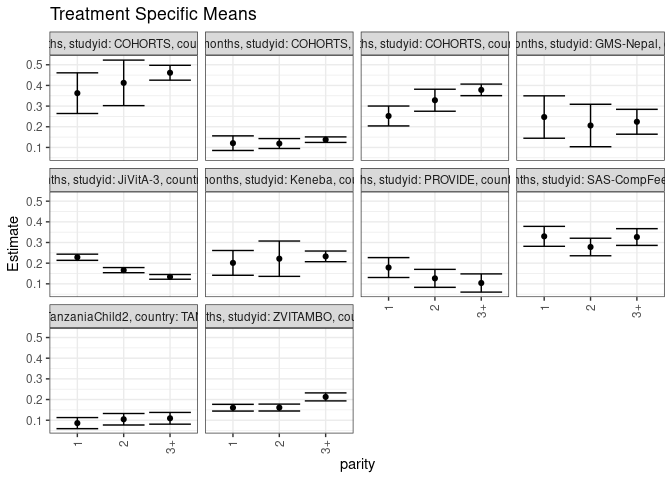

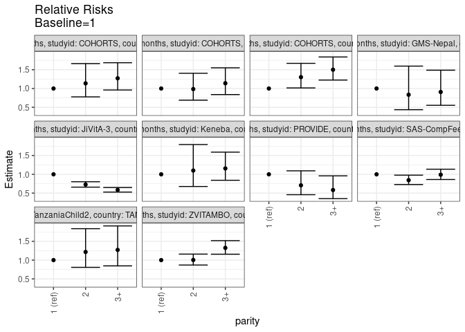

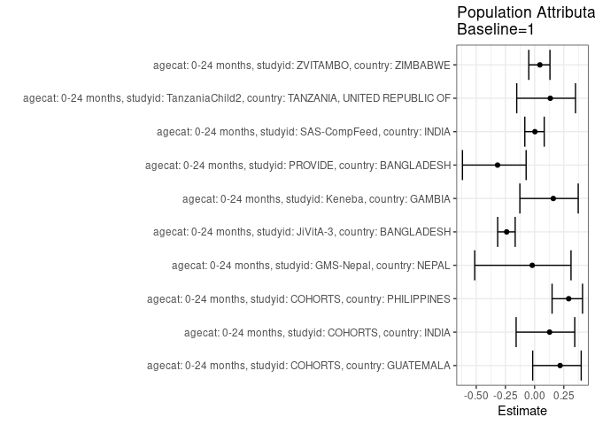

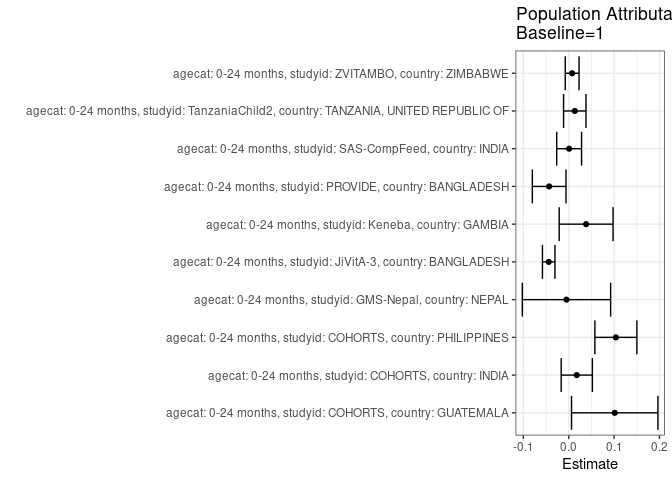

## Results Table

### Parameter: TSM

| agecat | studyid | country | intervention_level | baseline_level | estimate | ci_lower | ci_upper |
| --- | --- | --- | --- | --- | --- | --- | --- |
| 0-24 months | COHORTS | GUATEMALA | 1 | NA | 0.3625690 | 0.2641660 | 0.4609721 |
| 0-24 months | COHORTS | GUATEMALA | 2 | NA | 0.4123892 | 0.3022001 | 0.5225783 |
| 0-24 months | COHORTS | GUATEMALA | 3+ | NA | 0.4613566 | 0.4254317 | 0.4972814 |
| 0-24 months | COHORTS | INDIA | 1 | NA | 0.1206763 | 0.0853754 | 0.1559772 |
| 0-24 months | COHORTS | INDIA | 2 | NA | 0.1188373 | 0.0947545 | 0.1429201 |
| 0-24 months | COHORTS | INDIA | 3+ | NA | 0.1376065 | 0.1243051 | 0.1509078 |
| 0-24 months | COHORTS | PHILIPPINES | 1 | NA | 0.2521194 | 0.2040122 | 0.3002267 |
| 0-24 months | COHORTS | PHILIPPINES | 2 | NA | 0.3283330 | 0.2750516 | 0.3816145 |
| 0-24 months | COHORTS | PHILIPPINES | 3+ | NA | 0.3784071 | 0.3504905 | 0.4063237 |
| 0-24 months | GMS-Nepal | NEPAL | 1 | NA | 0.2470339 | 0.1444294 | 0.3496383 |
| 0-24 months | GMS-Nepal | NEPAL | 2 | NA | 0.2061422 | 0.1033807 | 0.3089037 |
| 0-24 months | GMS-Nepal | NEPAL | 3+ | NA | 0.2241721 | 0.1640403 | 0.2843039 |
| 0-24 months | JiVitA-3 | BANGLADESH | 1 | NA | 0.2285526 | 0.2136126 | 0.2434927 |
| 0-24 months | JiVitA-3 | BANGLADESH | 2 | NA | 0.1661641 | 0.1537556 | 0.1785725 |
| 0-24 months | JiVitA-3 | BANGLADESH | 3+ | NA | 0.1337106 | 0.1222191 | 0.1452022 |
| 0-24 months | Keneba | GAMBIA | 1 | NA | 0.2013085 | 0.1413558 | 0.2612611 |
| 0-24 months | Keneba | GAMBIA | 2 | NA | 0.2215143 | 0.1360002 | 0.3070284 |
| 0-24 months | Keneba | GAMBIA | 3+ | NA | 0.2328497 | 0.2071038 | 0.2585955 |
| 0-24 months | PROVIDE | BANGLADESH | 1 | NA | 0.1787708 | 0.1306366 | 0.2269050 |
| 0-24 months | PROVIDE | BANGLADESH | 2 | NA | 0.1264359 | 0.0830147 | 0.1698570 |
| 0-24 months | PROVIDE | BANGLADESH | 3+ | NA | 0.1039724 | 0.0599025 | 0.1480422 |
| 0-24 months | SAS-CompFeed | INDIA | 1 | NA | 0.3297921 | 0.2816074 | 0.3779768 |
| 0-24 months | SAS-CompFeed | INDIA | 2 | NA | 0.2781664 | 0.2357632 | 0.3205695 |
| 0-24 months | SAS-CompFeed | INDIA | 3+ | NA | 0.3263763 | 0.2859031 | 0.3668494 |
| 0-24 months | TanzaniaChild2 | TANZANIA, UNITED REPUBLIC OF | 1 | NA | 0.0859219 | 0.0590450 | 0.1127988 |
| 0-24 months | TanzaniaChild2 | TANZANIA, UNITED REPUBLIC OF | 2 | NA | 0.1046087 | 0.0768022 | 0.1324151 |
| 0-24 months | TanzaniaChild2 | TANZANIA, UNITED REPUBLIC OF | 3+ | NA | 0.1092658 | 0.0808925 | 0.1376391 |
| 0-24 months | ZVITAMBO | ZIMBABWE | 1 | NA | 0.1605322 | 0.1442613 | 0.1768031 |
| 0-24 months | ZVITAMBO | ZIMBABWE | 2 | NA | 0.1611912 | 0.1445275 | 0.1778549 |
| 0-24 months | ZVITAMBO | ZIMBABWE | 3+ | NA | 0.2128129 | 0.1934494 | 0.2321764 |

### Parameter: E(Y)

| agecat | studyid | country | intervention_level | baseline_level | estimate | ci_lower | ci_upper |
| --- | --- | --- | --- | --- | --- | --- | --- |
| 0-24 months | COHORTS | GUATEMALA | NA | NA | 0.4639706 | 0.4374564 | 0.4904847 |
| 0-24 months | COHORTS | INDIA | NA | NA | 0.1384449 | 0.1284958 | 0.1483940 |
| 0-24 months | COHORTS | PHILIPPINES | NA | NA | 0.3561151 | 0.3391405 | 0.3730897 |
| 0-24 months | GMS-Nepal | NEPAL | NA | NA | 0.2421203 | 0.2103189 | 0.2739218 |
| 0-24 months | JiVitA-3 | BANGLADESH | NA | NA | 0.1844493 | 0.1788538 | 0.1900447 |
| 0-24 months | Keneba | GAMBIA | NA | NA | 0.2396985 | 0.2209375 | 0.2584595 |
| 0-24 months | PROVIDE | BANGLADESH | NA | NA | 0.1357143 | 0.1103250 | 0.1611036 |
| 0-24 months | SAS-CompFeed | INDIA | NA | NA | 0.3307241 | 0.3024794 | 0.3589688 |
| 0-24 months | TanzaniaChild2 | TANZANIA, UNITED REPUBLIC OF | NA | NA | 0.0992787 | 0.0872038 | 0.1113537 |
| 0-24 months | ZVITAMBO | ZIMBABWE | NA | NA | 0.1681234 | 0.1619444 | 0.1743023 |

### Parameter: RR

| agecat | studyid | country | intervention_level | baseline_level | estimate | ci_lower | ci_upper |
| --- | --- | --- | --- | --- | --- | --- | --- |
| 0-24 months | COHORTS | GUATEMALA | 1 | 1 | 1.0000000 | 1.0000000 | 1.0000000 |
| 0-24 months | COHORTS | GUATEMALA | 2 | 1 | 1.1374088 | 0.7777389 | 1.6634101 |
| 0-24 months | COHORTS | GUATEMALA | 3+ | 1 | 1.2724654 | 0.9604003 | 1.6859305 |
| 0-24 months | COHORTS | INDIA | 1 | 1 | 1.0000000 | 1.0000000 | 1.0000000 |
| 0-24 months | COHORTS | INDIA | 2 | 1 | 0.9847608 | 0.6903616 | 1.4047042 |
| 0-24 months | COHORTS | INDIA | 3+ | 1 | 1.1402939 | 0.8387755 | 1.5502006 |
| 0-24 months | COHORTS | PHILIPPINES | 1 | 1 | 1.0000000 | 1.0000000 | 1.0000000 |
| 0-24 months | COHORTS | PHILIPPINES | 2 | 1 | 1.3022918 | 1.0154642 | 1.6701365 |
| 0-24 months | COHORTS | PHILIPPINES | 3+ | 1 | 1.5009041 | 1.2248515 | 1.8391724 |
| 0-24 months | GMS-Nepal | NEPAL | 1 | 1 | 1.0000000 | 1.0000000 | 1.0000000 |
| 0-24 months | GMS-Nepal | NEPAL | 2 | 1 | 0.8344692 | 0.4361865 | 1.5964248 |
| 0-24 months | GMS-Nepal | NEPAL | 3+ | 1 | 0.9074548 | 0.5534904 | 1.4877840 |
| 0-24 months | JiVitA-3 | BANGLADESH | 1 | 1 | 1.0000000 | 1.0000000 | 1.0000000 |
| 0-24 months | JiVitA-3 | BANGLADESH | 2 | 1 | 0.7270277 | 0.6587802 | 0.8023456 |
| 0-24 months | JiVitA-3 | BANGLADESH | 3+ | 1 | 0.5850322 | 0.5270055 | 0.6494479 |
| 0-24 months | Keneba | GAMBIA | 1 | 1 | 1.0000000 | 1.0000000 | 1.0000000 |
| 0-24 months | Keneba | GAMBIA | 2 | 1 | 1.1003723 | 0.6755939 | 1.7922293 |
| 0-24 months | Keneba | GAMBIA | 3+ | 1 | 1.1566809 | 0.8416846 | 1.5895631 |
| 0-24 months | PROVIDE | BANGLADESH | 1 | 1 | 1.0000000 | 1.0000000 | 1.0000000 |
| 0-24 months | PROVIDE | BANGLADESH | 2 | 1 | 0.7072514 | 0.4576573 | 1.0929676 |
| 0-24 months | PROVIDE | BANGLADESH | 3+ | 1 | 0.5815960 | 0.3526644 | 0.9591383 |
| 0-24 months | SAS-CompFeed | INDIA | 1 | 1 | 1.0000000 | 1.0000000 | 1.0000000 |
| 0-24 months | SAS-CompFeed | INDIA | 2 | 1 | 0.8434598 | 0.7280162 | 0.9772095 |
| 0-24 months | SAS-CompFeed | INDIA | 3+ | 1 | 0.9896425 | 0.8623715 | 1.1356965 |
| 0-24 months | TanzaniaChild2 | TANZANIA, UNITED REPUBLIC OF | 1 | 1 | 1.0000000 | 1.0000000 | 1.0000000 |
| 0-24 months | TanzaniaChild2 | TANZANIA, UNITED REPUBLIC OF | 2 | 1 | 1.2174856 | 0.8073236 | 1.8360312 |
| 0-24 months | TanzaniaChild2 | TANZANIA, UNITED REPUBLIC OF | 3+ | 1 | 1.2716875 | 0.8467795 | 1.9098114 |
| 0-24 months | ZVITAMBO | ZIMBABWE | 1 | 1 | 1.0000000 | 1.0000000 | 1.0000000 |
| 0-24 months | ZVITAMBO | ZIMBABWE | 2 | 1 | 1.0041051 | 0.8689737 | 1.1602504 |
| 0-24 months | ZVITAMBO | ZIMBABWE | 3+ | 1 | 1.3256710 | 1.1571084 | 1.5187892 |

### Parameter: PAR

| agecat | studyid | country | intervention_level | baseline_level | estimate | ci_lower | ci_upper |
| --- | --- | --- | --- | --- | --- | --- | --- |
| 0-24 months | COHORTS | GUATEMALA | 1 | NA | 0.1014016 | 0.0061907 | 0.1966124 |
| 0-24 months | COHORTS | INDIA | 1 | NA | 0.0177686 | -0.0165540 | 0.0520913 |
| 0-24 months | COHORTS | PHILIPPINES | 1 | NA | 0.1039957 | 0.0577088 | 0.1502826 |
| 0-24 months | GMS-Nepal | NEPAL | 1 | NA | -0.0049135 | -0.1022393 | 0.0924122 |
| 0-24 months | JiVitA-3 | BANGLADESH | 1 | NA | -0.0441034 | -0.0578852 | -0.0303216 |
| 0-24 months | Keneba | GAMBIA | 1 | NA | 0.0383900 | -0.0209598 | 0.0977399 |
| 0-24 months | PROVIDE | BANGLADESH | 1 | NA | -0.0430565 | -0.0801824 | -0.0059306 |
| 0-24 months | SAS-CompFeed | INDIA | 1 | NA | 0.0009320 | -0.0264639 | 0.0283279 |
| 0-24 months | TanzaniaChild2 | TANZANIA, UNITED REPUBLIC OF | 1 | NA | 0.0133568 | -0.0113180 | 0.0380317 |
| 0-24 months | ZVITAMBO | ZIMBABWE | 1 | NA | 0.0075912 | -0.0076400 | 0.0228224 |

### Parameter: PAF

| agecat | studyid | country | intervention_level | baseline_level | estimate | ci_lower | ci_upper |
| --- | --- | --- | --- | --- | --- | --- | --- |
| 0-24 months | COHORTS | GUATEMALA | 1 | NA | 0.2185517 | -0.0163439 | 0.3991586 |
| 0-24 months | COHORTS | INDIA | 1 | NA | 0.1283443 | -0.1580953 | 0.3439369 |
| 0-24 months | COHORTS | PHILIPPINES | 1 | NA | 0.2920283 | 0.1496972 | 0.4105347 |
| 0-24 months | GMS-Nepal | NEPAL | 1 | NA | -0.0202938 | -0.5129452 | 0.3119384 |
| 0-24 months | JiVitA-3 | BANGLADESH | 1 | NA | -0.2391084 | -0.3164014 | -0.1663536 |
| 0-24 months | Keneba | GAMBIA | 1 | NA | 0.1601596 | -0.1261151 | 0.3736592 |
| 0-24 months | PROVIDE | BANGLADESH | 1 | NA | -0.3172583 | -0.6178154 | -0.0725385 |
| 0-24 months | SAS-CompFeed | INDIA | 1 | NA | 0.0028180 | -0.0836870 | 0.0824178 |
| 0-24 months | TanzaniaChild2 | TANZANIA, UNITED REPUBLIC OF | 1 | NA | 0.1345388 | -0.1529021 | 0.3503151 |
| 0-24 months | ZVITAMBO | ZIMBABWE | 1 | NA | 0.0451523 | -0.0498442 | 0.1315530 |